# Dumb and Dumber: The Impact of Downsizing on Firm Performance as Moderated by Industry Conditions

Page 1

### Dumb and Dumber: The Impact of Downsizing on Firm Performance as Moderated by Industry Conditions

### Author(s): James P. Guthrie and Deepak K. Datta

### Source: Organization Science , Jan. - Feb., 2008, Vol. 19, No. 1 (Jan. - Feb., 2008), pp. 108-123

### Published by: INFORMS

### Stable URL: https://www.jstor.org/stable/25146166

Page 2

### Organization Science infiT?nT3

Vol. 19, No. 1, January-February 2008, pp. 108-123 ^ i0.i287/orsc.l070.0298

issn 1047-70391 eissn 1526-54551081190110108 @ 200g INFORMS

## Dumb and Dumber: The Impact of Downsizing on Firm

## Performance as Moderated by Industry Conditions

#### James P. Guthrie

School of Business, University of Kansas, Lawrence, Kansas 66045, jguthrie@ku.edu

### Deepak K. Datta Department of Management, College of Business Administration, University of Texas at Arlington,

Arlington, Texas 76019, ddatta@uta.edu

Workforce downsizing through employee layoffs has become commonplace in American businesses over the last 20 years. While these initiatives are typically undertaken in the quest for improved firm performance and compet

itiveness, empirical research to date has been equivocal in supporting the efficacy of these initiatives. In addition, extant

research has not thoroughly examined factors or conditions that may influence or moderate the performance impact of

workforce downsizing. In this paper, we address the question: Do industry conditions moderate the impact of workforce

downsizing on firm performance? We examine this question using matched primary and secondary data on a sample of

U.S. manufacturing firms. After controlling for a set of industry and firm-level variables, including firms' prior performance

levels, our results indicate that downsizing is associated with decreases in subsequent firm profitability and that these

negative effects are more pronounced in industries characterized by research and development (R&D) intensity, growth,

and low capital intensity.

Key words: downsizing; industry; firm performance

History: Published online in Articles in Advance December 11, 2007.

Some executives are concluding that the corporations of

the future... will need to be more like nomadic tribes,

pitching their tents anywhere on a moment's notice, and

less like plodding agriculturalists, rooted to one place

and one core competence. This may seem a reasonable

response to the increasing disorder and confusion of the

business world. And the picture it paints of dynamic

flexibility and adventurous energy may be very attrac

tive. But consider how little progress nomadic tribes have

made compared to the great civilizations with their endur

ing institutions, their sciences and cities, their ability to

cope with change from a stable base. (Reichheld 1996, p. 93)

Millions of American workers have been laid off or

downsized over the years, a trend that shows no sign of abatement.1 Although often undertaken as a means of ensuring or improving future organizational perfor mance, it is not clear that reducing headcount achieves

this intended outcome. In fact, it has been argued that firms that downsize "rather than becoming lean and

mean, often end up lean and lame" (Henkoff 1994, p. 58).

Relative to the frequency of its occurrence, empirical

research on the phenomenon of downsizing remains lim

ited. In 1994, Cameron described downsizing as the "most pervasive yet under-studied phenomenon in the business world" (1994, p. 183). This viewpoint is echoed by Budros (1999, p. 69), who comments that "although downsizing has become an integral part of organizational

life in the U.S. there is little serious theoretical or empir ical work on this issue." A number of studies have been

conducted in the ensuing years, yet the topic remains underresearched and extant findings somewhat equivo

cal. The interested reader can find studies suggesting

that downsizing has positive effects (Wayhan and Werner 2000), negative effects (Cascio et al. 1997), or no effects

(Cameron et al. 1991) on firm performance. In addi tion, with some exceptions (e.g., Chadwick et al. 2004,

Nixon et al. 2004), research to date has not systematically

examined organizational practices or contextual condi

tions that may influence the effectiveness of employee downsizing.

Using contingency theory as our overarching frame work, in this paper we seek to contribute to this litera

ture by examining whether industry conditions moderate

the impact of downsizing on firm performance. Although underrepresented in strategic human resource manage ment (SHRM) research, the strategic management and

industrial organization literature (e.g., Porter 1980) con siders a firm's industry to have an important impact on both the incidence and effectiveness of organiza

tional initiatives. In focusing on the relationships between

industry characteristics, workforce downsizing, and orga nizational effectiveness, our work builds on and extends

research on the effectiveness of downsizing and, more generally, SHRM.

108

Page 3

Guthrie and Datta: The Impact of Downsizing on Firm Performance

Organization Science 19(1), pp. 108-123, ?2008 INFORMS 109

The paper unfolds as follows: First, we briefly discuss the extant literature on downsizing and the implications of downsizing for firm performance. We then develop arguments and hypotheses proposing that industry con ditions will moderate the downsizing-firm performance

relationship. Next, we describe our methodology, includ

ing sample selection, the operationalization of variables, and the analytical methods used in our study. Finally, we discuss our results and conclude by discussing the impli cations of our study for practice and future research.

### Workforce Downsizing: Theory and

### Past Research

Employee downsizing has been defined as the planned

reduction in jobs and personnel (Cascio 1993). In his book, The New Deal at Work, Cappelli (1999) reviews

evidence related to the issue of whether the stability of employment relationships in the United States has

changed in recent years. Although some may question

the magnitude of change, Cappelli makes a compelling case that change has indeed occurred. For example, 10 of the 100 best companies to work for in America, as

identified in Levering and Moskowitz rankings, in 1993 had explicit "no-layoff" policies; in 1997 only two firms within this group had such a stated policy (Levering and Moskowitz 1993, 1997).

The trend toward employee reductions for reasons other than job performance (i.e., downsizing) began

in earnest during the early 1980s, when many firms found themselves in the throes of a significant economic downturn. Often in the context of declining revenues, downsizing during this period was driven primarily by managers' beliefs and expectations that downsizing

could preserve profitability by enhancing organizational efficiency and reducing costs (DeWitt 1998, Freeman

1994, Harrigan 1980). Because downsizing during this era was prompted by dramatic slowdowns in business, it was thought to be temporary in nature. Even after eco

nomic recovery, however, the ensuing years witnessed continued and significant job loss. In fact, permanent job displacement in the United States was higher between

1993-1995, a notable period of economic expansion, than between 1981-1983, a period of deep economic re cession (Farber 1997). Downsizing in such contexts is

seen as a proactive means to maintain firm performance (McKinley et al. 1998, Murray 1995). Although layoffs may be prompted by desires to restructure and "right

size," the frequency of downsizing in recent years may also be partly attributable to mimetic isomorphism (herd behavior), with organizations responding to institutional

forces. In this view, downsizing became institutional

ized and imparted legitimacy to organizations that prac ticed it, thus increasing its use (Budros 1999, McKinley et al. 2000).

In the SHRM literature, authors suggest that work force reductions and employment instability will tend to

negatively impact organizational functioning. For exam ple, a central thesis of Frederick Reichheld's book, The Loyalty Effect, is that sustainable organizational success

is increasingly dependent on what he terms "loyalty management." As with other authors (e.g., Pfeffer 1998),

Reichheld argues that intellectual capital and human

assets are becoming increasingly important in today's dynamic, hypercompetitive marketplace. He goes on to

argue that long-term competitive advantage in today's environment depends fundamentally on capturing the

inherent value in the tacit knowledge and relationships developed by employees over time.

One of the greatest problems with the old approach to

productivity, which focused primarily on costs, is that manufacturing, at least in the nineteenth century, saw

workers as easily replaceable. For the most part, expe

rience and learning were captured in the architecture of

the machine and the process design of the factory. Today, in services and in the service functions within manu

facturing, the learning curve is individual, has a pro found effect on both revenues and costs, and is longer and steeper by far than it was in the age of manufac

turing. It grows out of the cumulative decision-making experience an employee builds over time through rela

tionships with customers, vendors and fellow employees. (Reichheld 1996, p. 122)

In a similar vein, Pfeffer (1998) in his book, The Human Equation, argues that the current practice of

diminished employment security is contrary to effective human resource management (HRM). He sees employ ment security as a quid pro quo to assure workers that

their efforts to increase productivity and efficiency? especially critical in today's competitive marketplace? will not ultimately lead to employee attrition. Pfeffer

views employment security as a practice that will, over

time, build trust between workers and employers, ulti mately yielding greater cooperation and a better esprit

d'corps. This, in turn, will enhance the mutual com mitment needed to effectively capitalize on the use of

delegated decision-making authority, teams, information

sharing, and other workplace innovations.

Not everyone agrees, however, that downsizing and unstable employment relationships will negatively affect firm performance. Indeed, as noted, firms undertake downsizing with the expectation that they will experi

ence financial and organizational benefits (Bruton et al.

#### 1996; Cascio 1993, 2002; Kets de Vries and Balzas

1997). The starting point for this rationale is that prof its are achieved when revenues exceed costs, an out

come obtained by increasing revenues, decreasing costs, or both. As noted by Cascio (2002), because revenues are much less predictable and controllable than costs, managers seeking to increase profits will often do so

by reducing headcount and labor costs. Thus, down

sizing is often motivated by a desire to reduce labor expenses to stem eroding profitability and/or increase

Page 4

Guthrie and Datta: The Impact of Downsizing on Firm Performance

110 Organization Science 19(1), pp. 108-123, ?2008 INFORMS

future profitability. In increasingly competitive markets, "downsizing has turned into one of the inevitable out comes of living in a global world where continual adjust ments to products, services, and the price of labor are

needed to remain competitive" (Kets de Vries and Balzas

1997, p. 12).

The relative contribution of employment security to organizational effectiveness is a central concern ad dressed by Cappelli (1999). In sharp contrast with Pfeffer (1998) and Reichheld (1996), Cappelli concludes

that emphasizing employment security and long-term relationships is not particularly important in today's "new economy." He notes that the "new deal" in employment relationships is so widespread that very few employees expect a commitment toward long-term employment as part of their psychological contract with employers. In discussing Reichheld's (1996) stance on

the efficacy of loyalty-based management, Cappelli con cedes that although there may be some advantages in having long-term relationships with employees, there

are potentially high opportunity costs associated with maintaining the status quo in dynamic, competitive

environments: "Keeping long-term employees does not necessarily mean that organizations cannot restructure

and change their competencies, although it does vastly complicate the challenge of doing so" (1999, p. 223).

Downsizing and Firm Performance:

#### The Empirical Evidence As noted, firms often reduce personnel as a form of

restructuring in pursuit of improved performance. The

stated objective of employee downsizing is often the enhancement of competitiveness via productivity and profitability improvements brought about by eliminat

ing people and/or jobs deemed redundant or unnecessary (DeWitt 1998, Freeman and Cameron 1993). How ever, as indicated by the fact that both Pfeffer (1998) and Cappelli (1999) invoke studies within this litera

ture stream to support their contrary arguments, results to date can be characterized as somewhat equivocal. Articles have appeared in the popular business press

extolling the benefits of downsizing (Bryne 1994, Fuchsberg 1993, Koretz 1997). It has been argued that

downsizing reduces organizational slack and operating

costs, streamlines operations, and enhances effective ness toward making an organization more competitive. Studies that support the position that downsizing can

improve aspects of organizational efficiency or effective ness include those by Baumol et al. (2003), Espahbodi et al. (2000), and Wayhan and Werner (2000). Espahbodi et al. (2000) and Wayhan and Werner (2000) provide

the most positive results. Baumol et al. (2003), on the other hand, find that although labor productivity (output per worker) declines following downsizing, this is offset by savings in unit labor costs, with market value being unaffected. Similarly, Cappelli (2000) finds that although

labor productivity decreases following downsizing, there are also reductions in labor costs. Several studies, how

ever, suggest neutral to negative performance effects for downsizing (e.g., Cascio et al. 1997), and this is gen

erally more true for "event studies" examining stock market reactions to downsizing announcements (Caves

and Krepps 1993, Lee 1997, Nixon et al. 2004, Palmon et al. 1997, Worrel et al. 1991). Chadwick et al. recently

reviewed the existing research and concluded:

Despite the popularity of downsizing as a strategic initia

tive, however, the general consensus among researchers over the past two decades is that organizational perfor mance is as likely to suffer as it is to improve after

downsizing, even in the short term, and that the long

term prospects associated with downsizing are decidedly negative when compared to alternatives such as targeting growth.... (2004, p. 406)

In reviewing all the relevant literature, our conclusion is that downsizing will, more often than not, tend to negatively impact firm performance. However, given the equivocal findings in previous studies, it is quite likely

that the effects of downsizing on performance "depend" or "are contingent on" contextual factors. To date, how ever, few downsizing studies have studied moderating factors. One recent exception is Chadwick et al. (2004), who found that the performance effects of downsizing

depend on the manner in which it is carried out. In

this paper we consider the role of industry character istics in understanding the performance implications of downsizing.

Downsizing Under Different Industry Conditions: A Contingency Framework

way"?the effectiveness of an organizational structure

depends on a firm's set of contextual conditions. In the

ensuing years, contingency theory has continued to be an important component of organization design theo ries but has also been applied more generally to vari ous aspects of managerial decision and policy making

(recent empirical articles invoking contingency theory include Baum and Stefan 2003, Datta et al. 2005, Datta

and Rajagopalan 1998, Hambrick and Cannella 2004, Siegel and Hambrick 2005). More recently, the resource based view of the firm (RBV) also incorporates a contin gency perspective, holding that organizational resources can be a source of sustainable competitive advantage to

the extent that they create value and allow a firm to excel in its particular competitive environment. Consis

tent with the tenets of contingency theory, we argue that

Page 5

Guthrie and Datta: The Impact of Downsizing on Firm Performance

Organization Science 19(1), pp. 108-123, ?2008 INFORMS 111

the relative effectiveness of human resource (HR) poli cies, such as employment stability and downsizing, will be influenced by a firm's industry context.

In the SHRM literature, conceptual treatments have emphasized the influence of environmental conditions on HR configurations and effectiveness (e.g., Bamberger

and Meshoulam 2000, Lepak and Snell 1999, Wright and Snell 1998), but empirical work has only sporadi cally examined the influence of industry conditions on

the practice and effectiveness of HRM. Examples of studies examining industry effects in the SHRM liter ature include research on the impact of industry envi

ronment on staffing patterns and practices (e.g., Guthrie and Olian 1991, Guthrie et al. 1991), employment modes (Lepak et al. 2003), and HR strategy (Bamberger

and Phillips 1991). Most recently, studies have begun

to examine whether industry conditions moderate the impact of HRM on firm performance. Examples include studies by Batt (2002), who explored the moderating effects of market segment on the HR-firm performance relationship, and Datta et al. (2005), who examined the strength of the HRM-firm productivity link across dif

ferent industry conditions.

Research on the implications of industry structure on downsizing is particularly limited. An exception is the

study conducted by Filatotchev et al. (2000), who found

industry decline to be a major factor in downsizing among privatized firms in Russia, Ukraine, and Belarus. Because industry conditions are widely acknowledged to have key influences on managerial actions and firm strat

egy, we believe that industry and market characteristics

should play a more prominent role in macro-level HRM research.

The literature in industrial organization economics (Bain and Quails 1987, Scherer 1980), competitive strat egy (Porter 1980), and organizational theory (Pfeffer and Salancik 1978, Thompson 1967) suggests that the effectiveness of managerial policies and decisions can be meaningfully studied in the context of key industry

structure dimensions, including product differentiability (proxied by industry R&D intensity), industry growth rate, capital intensity, and demand instability. From a contingency perspective, these (and other) industry char acteristics pose different types of uncertainties and chal

lenges (Thompson 1967), so that the effectiveness of managerial decisions is largely dependent on the nature

of this environmental contingency. Thus, from a norma

tive perspective, industry factors influence the type of competitive behavior considered appropriate in an indus

try. Against the general backdrop of contingency theory, we propose that the affect of employment instability and

employee downsizing on firm performance depends on

the characteristics of the industry.

In addition to contingency theory, the RBV of the firm also provides important insights. Building on the early

work of Selznick (1957) and Penrose (1959) and fur

ther work by Wernerfelt (1984), the RBV argues that firms derive competitive advantage from unique resource endowments. Consistent with the tenets of contingency

theory, recent scholarship indicates that the value of these organizational resources and associated strategic decision making is affected by environmental condi

tions (e.g., Aragon-Correa and Sharma 2003). Grant (2005) classifies value-adding resources as tangible, intangible, and HR. HR represents the productive ser vices that employees offer the firm in terms of their

skills, knowledge, reasoning, and decision-making abil

ities. In an organizational context, employees not only contribute their individual skills and knowledge, they also collaborate and integrate their separate skills toward creating firm capabilities. As such, both human and

social capital?and therefore the commitment and the loyalty of employees?play an important role in dictat ing a firm's capacity to create competitive advantage. Reducing headcount may lead to immediate labor cost

savings, but it can also seriously erode employee com mitment and loyalty, with negative consequences for

firm competitiveness and performance. Consistent with

the contingent notions within the RBV, we argue that industry differences will modify the performance conse quences of human and social capital losses and the ero

sion of remaining employees' commitment and loyalty.

These ideas are incorporated in discussions of organi zational social capital. Organizational social capital "re flects the character of social relations within a firm"

(Leana and Van Buren 2000, p. 221) and has two primary components: associability and trust. Associability refers

to employees' willingness to interact with organizational members and to subordinate individual goals to collec

tive goals. Generalized resilient trust exists when values of reciprocity exist among organizational members by virtue of their being a member of the same organiza

tional community. Invoking the notion of psychological contracts (De Meuse and Tornow 1990, Morrison and Robinson 1997, Rousseau 1995), Leana and Van Buren

explicitly discuss the likely impact on social capital of a psychological contract that emphasizes job instability and employ ability as "part of the deal":

... there is little room for norms of reciprocity, resilient trust, or associability in a psychological contract that emphasizes employees' ability to maintain their skills so

that they will be ready at any time to find work with another organization. (2000, p. 224)

We believe that this type of psychological contract will

be particularly harmful in some industry contexts.

#### Research Hypotheses

Industry R&D Intensity. R&D intensity is widely used as an indicator of industry differentiation (e.g.,

Page 6

Guthrie and Datta: The Impact of Downsizing on Firm Performance

112 Organization Science 19(1), pp. 108-123, ?2008 INFORMS

Hambrick and Finkelstein 1987). Though firms in undif

ferentiated industries tend to have relatively similar, commodity-like products, competitive success in more differentiated industries hinges on having products that

stand out from competitors' on the basis of product fea tures, quality, design, etc. Differentiated industries offer more avenues for competition and a wider range of fea

sible competitive actions, with means-end linkages being relatively ambiguous (Porter 1980). Thus, on average, firms in differentiated industries shift production and organizational processes more frequently in pursuit of

innovations and to meet changing market and customer preferences. Moreover, jobs tend to be more complex

and varied, requiring both deeper and broader skill and knowledge sets and the ability and willingness to suc

ceed in more challenging and varying circumstances.

"The free-market mechanism creates remorseless

pressures for innovation..." (Baumol et al. 2003, p. 11),

and this is particularly true in R&D-intensive indus

tries. Knowledge in such industries might be embed ded in organizational routines and processes, yet it often

resides in the form of tacit knowledge in a firm's human and social capital. Unique HR endowments possessed by firms in R&D-intensive industries are central to

achieving and sustaining competitive advantage. The dis ruptions to organizational social capital engendered by downsizing may, therefore, prove particularly problem

atic for knowledge-intensive firms. Knowledge workers

tend to exhibit greater loyalty to their peers and pro fession than to their employers (Dess and Shaw 2001),

so practices reducing organizational commitment and emphasizing employability as part of the psychological contract may lead to critical losses among this group of employees. Moreover, downsizing and the associated damage to a firm's social capital may lead to the loss of knowledge stored in transitive (social system) mem ory and negatively impact the ability of firms to derive value from knowledge gained from brokered relation

ships (Burt 1997, Dess and Shaw 2001).

In R&D-intensive industries, employees' creativity and innovation are relatively more central, suggest

ing that threat-rigidity responses resulting from down sizing may diminish the organizational resource most critical for creating and sustaining competitive advan

tage (Amabile and Conti 1999, Cascio 2002). Indeed, empirical evidence supports the belief that creativity declines during the downsizing process, with "survivors"

exhibiting behavioral rigidity (Cameron et al. 1987) and risk aversion (Cascio 1993). Additional support comes from the work of Dougherty and Bowman (1995), who found that downsizing hinders product innova

tion in organizations. The process-dependent nature of workforce peer relations in technologically intensive

industries also means that any disruptions triggered by downsizing will likely have a major impact on firm out

comes. In R&D-intensive industries, social dynamics are

often central to the innovation process; thus, disruptions engendered by downsizing will be particularly perni cious. All of these outcomes should be particularly detri mental in R&D-intensive industries. Cascio makes this

explicit argument and writes: "Which kinds of organiza

tions are at greatest risk? Those that operate in rapidly evolving industries, such as biotechnology, pharmaceuti cals, and software, in which survival depends on a firm's ability to innovate constantly" (2002, pp. 33-34). In

sum, workforce downsizing should be particularly dele terious in R&D-intensive industries. Thus:

Hypothesis 1. Industry R&D intensity will moderate the relationship between workforce downsizing and firm performance such that downsizing will be more detri mental for firms in industries that are characterized by

high R&D intensity as opposed to firms in industries characterized by low R&D intensity.

Industry Growth. Similar arguments can also be made in the context of market growth, an industry charac teristic that features prominently in industrial organiza tion and strategic management literature (Porter 1980). Demand growth has been associated with greater market

opportunity and competitive variation (e.g., Datta and Rajagopalan 1998), providing managers and employ

ees with more discretionary opportunities. High-growth

industries are characterized by decision making in the entrepreneurial mode, with greater opportunities for industry initiatives and decision-making freedom. Hambrick and Finkelstein (1987) suggest that industry

growth results in an expanded set of options for firms,

reducing the tendency for organization inertia. These

industry features are associated with market and orga nizational variability and enhanced discretion, increas

ing the relative benefit derived from employee initiatives and contributions. The ability to adapt quickly to emerg

ing market conditions in growth industries is crucial for competitive success. Organizations in high-growth environments are also likely to value innovation and change (Chatman and Jehn 1994), magnifying the neg ative impact of behavioral rigidity (Amabile and Conti

1999). As noted above, if downsizing erodes human and social capital, then the diminution of these criti cal resources will be particularly harmful in high-growth

industries.

Moreover, although some firms do restructure and downsize in the face of strong market demand, the eco nomic rationale for reducing headcount and associated

labor costs is much more readily apparent in the con text of slow or shrinking demand. In the interest of pre serving profitability, reduced market demand in mature industries may signal a need to lower firm expenses, including labor costs, through "selective shrinking" (Harrigan 1980).

Under circumstances of a business downturn, employ ees may be more inclined to view layoffs as justified

Page 7

Guthrie and Datta: The Impact of Downsizing on Firm Performance

Organization Science 19(1), pp. 108-123, ?2008 INFORMS 113

(Cascio 2002, Charness and Levine 2000). In contrast, employees?both those laid off and those retained? are more likely to view layoffs in the face of market growth as violating or reneging on the psychological contract between workers and the employer (Morrison and Robinson 1997). This may magnify the negative

impact of downsizing on employee morale and commit ment and increase rigid, inflexible behavior, resulting

in a reduced ability to capture market share and rev enue. In addition, in high-growth industries there is an

increased likelihood of "downsized" employees being hired by market competitors. This might give these com petitors access to valuable competitive intelligence and proprietary information. Moreover, if organizations in

such industries eventually elect to replace downsized employees, finding qualified individuals might prove to be challenging, time consuming, and expensive.

In sum, from both a psychological and rational eco nomic perspective, layoffs would appear less appropriate under conditions of market growth. Thus:

Hypothesis 2. Industry growth will moderate the relationship between workforce downsizing and firm per formance such that downsizing will be more detrimental for firms in industries that are characterized by high

growth as opposed to firms in industries characterized by low growth.

Industry Capital Intensity. Another important indus try characteristic is capital intensity, a measure of the relative investment in fixed assets in an industry. As discussed in the strategy literature (e.g., Datta and Rajagopalan 1998, Hambrick and Lei 1985), capital

intensity often creates strategic rigidity because fixed costs are high and deviations tend to be expensive. Al

though directed primarily at the impact of organizational leadership on firm performance, the consistent argument in this literature is that the "rigidity" associated with higher levels of capital intensity reduces the performance effects associated with variability in a firm's stock of human capital.

Similar arguments can be found in the SHRM liter ature. Terpstra and Rozell, for example, argue that in capital-intensive industries, there are "greater constraints placed upon employee performance by the degree of task

structure or the degree of automation of the production technology" (1993, p. 43). As capital intensity increases, the human element becomes less integral to the produc tion process. These arguments are consistent with argu ments and results presented by Datta et al. (2005), who

found that capital intensity moderated the impact of HR

systems on firm productivity. Specifically, they found that high-performance HR systems were relatively more beneficial in industries characterized by lower levels of capital intensity.

Similarly, we believe that industry capital intensity will moderate the relationship between workforce down

sizing and firm performance, with the loss of human

and social capital being relatively more benign in indus

tries where physical capital is more important to the production process. As the relative proportion of human vis-a-vis physical assets increases, the disruptive impact of downsizing on organizational social capital and orga nizational functioning should also increase. As noted, organizational social capital is the aggregate quality of

social relationships within a firm. Labor capital-intensive firms are more susceptible to value loss due to social network disruptions. Thus,

Hypothesis 3. Industry capital intensity will moder ate the relationship between workforce downsizing and firm performance such that downsizing will be more

detrimental for firms in industries that are characterized by low capital intensity as opposed to firms in industries

characterized by high capital intensity.

Industry Dynamism. Finally, industry dynamism has also been postulated to have an important effect on

the nature of competition, defining the extent to which a firm faces an environment that is predictable and

stable or changing and uncertain. A number of argu ments suggest that environmental dynamism may influ

ence the relative effectiveness of workforce downsizing. As in industries marked by growth and reduced capi

tal intensity, Hambrick and Finkelstein (1987) suggest that industry dynamism results in an expanded set of options for firms, reducing the tendency for organi zation inertia. By necessitating frequent strategic and

structural adaptations, turbulent environments increase

information-processing needs and complexity. In gen eral, skill requirements in more dynamic environments are likely to be more complex and varied, increasing the need for individuals with both the capacity and willing ness to deal with complexity and change.

A number of authors (e.g., Pfeffer 1998, Reichheld 1996) have argued forcefully that the challenges implied by increased market or industry volatility magnify the

importance of policies that engender employee commit ment. Moreover, these same authors identify employ ment security as a central component in obtaining

employee commitment in unstable markets. Pfeffer, for example, believes that firms in dynamic markets may benefit from avoiding cyclical layoffs. In review

ing Delery and Doty's (1996) finding that employment security in the banking industry improved profitability, Pfeffer writes:

Why might this be? In a bank that hires and lays off loan

officers quickly to match economic fluctuations, the typ

ical loan officer will worry only about booking loans? just what they have typically been rewarded for doing. With employment security and a longer-term perspective

on the job, the bank officer may be more inclined to worry as well about the repayment prospects of the loan

and about building customer relationships by providing high levels of service. (1998, p. 68)

Page 8

Guthrie and Datta: The Impact of Downsizing on Firm Performance

114 Organization Science 19(1), pp. 108-123, ?2008 INFORMS

According to Pfeffer, avoiding employment boom and-bust cycles not only brands firms as the "employer of choice" within these dynamic industries, it also helps firms avoid the trap of "buying high and selling low" in

the labor market. Emphasizing employability and unsta ble employment relationships as a part of the psycho

logical contract with employees is a strategy that firms adopt in an attempt to achieve flexibility. Leana and Van Buren (2000) argue, however, that by diminishing

"resilient trust," practices such as downsizing will, para doxically, often result in firms being less flexible and

adaptable. Thus, the erosion of organizational social cap

ital and increased tendency of employees to become more rigid under times of perceived threat or stress from

downsizing (Amabile and Conti 1999) should be partic ularly problematic in dynamic industry environments. In

sum, these arguments lead us to expect:

Hypothesis 4. Industry dynamism will moderate the

relationship between workforce downsizing and firm per formance such that downsizing will be more detrimental for firms in industries that are characterized by high

dynamism as opposed to firms in industries character

ized by low dynamism.

### Method

#### Sample and Data Collection The firms in the sample were selected based on sev

eral criteria. First, given that the manufacturing sec

tor has been particularly prone to downsizing (Baumol et al. 2003), we targeted publicly traded firms in this

sector having a minimum of 100 employees and $50 mil lion in sales. Second, because the influence of indus try characteristics can only be meaningfully assessed in nondiversified firms, the sample was limited to relatively nondiversified firms (operationalized as deriving at least 60% of sales revenues from a single four-digit standard

industrial classification (SIC) code). Third, because we wanted to examine and control for certain workforce

(employment security policies, level of unionization rep resentation) and firm (competitive strategy) character

istics, survey responses from firm representatives were required. As such, names and addresses of senior HR executives were obtained from the Directory of Corpo rate Affiliations, Hunt-Hanlon Select Guide to HR Exec utives, and the Society for Human Resource Management Membership Directory.

A total of 971 firms met the above criteria. A mail

survey, conducted during late 1999 and early 2000, col

lected 1999 data on firms from the identified HR execu

tives. Initial surveys were followed by a reminder letter, a second survey, and, finally, a telephone reminder. A total of 144 responses, representing a 15% response

rate, were received. However, missing values on the survey data and/or firm level data from the Compustat

database reduced the usable sample for analysis to 122 firms. This response rate is similar to responses to other HR-oriented surveys. Becker and Huselid (1998) found

surveys used to collect firm HR data had response rates ranging from 6% to 28%, with an average of 17.4%.

#### Measures

Firm Performance. Return on assets (ROA), mea sured as operating income (before depreciation, inter est, and taxes) divided by total assets, is the most widely used firm performance variable in management

research, including research that has examined the per formance consequences of downsizing (e.g., Cascio et al.

1997). Firms often reduce headcount to reduce costs and improve margins, so ROA seems a particularly appropriate choice as an outcome variable of interest. Accordingly, we used the mean ROA for the 3 years

(2000-2002) following the base year (1999) to measure post-downsizing firm performance. The use of multi ple years of performance following employee reductions provides a more robust test and is consistent with pre vious work (e.g., Cascio et al. 1997, Chadwick et al. 2004).

Because of skewness in this ROA measure among

sample firms (as indicated by the Kolmogorov-Smirnov statistic), we used the natural logarithm of the mean ROA in our analysis. In addition, we wanted to assess

the impact of workforce reductions on firm performance over and above previous firm performance. To accom plish this, we controlled for performance for a 3-year period prior to our postperformance measure. ROA data were obtained from the Compustat database, with pre

performance measured as the natural logarithm of the mean of ROA from 1997 to 1999.

Workforce Downsizing. To assess workforce downsiz ing, we examined the change in the level of year-end employment between 1998 and 1999. Consistent with previous work (Ahmadjian and Robinson 2001, Bruton

et al. 1996, Cascio et al. 1997, Wayhan and Werner 2000), we used employment-level change data to create a dichotomous variable representing firms that reduced

their workforce (=1) and those that did not (=0).2 Ahmadjian and Robinson (2001) also point out that a

dichotomous measure of downsizing is easier to inter pret than a continuous measure, which would reflect decreases and increases in employment.

Researchers have typically chosen a specific numer ical workforce reduction to represent downsizing. The most common cutoff is 5% (Ahmadjian and Robinson

2001, Cascio etal. 1997, Littler and Innes 2004, McKinley

et al. 1998, Morris et al. 1999). Both Ahmadjian and Robinson (2001) and Cascio et al. (1997) concluded that

a 5% reduction represents a significant event and likely

indicates an intentional reduction in employees, a hall mark of downsizing (Freeman and Cameron 1993). Con

sistent with this previous research, we used workforce

Page 9

Guthrie and Datta: The Impact of Downsizing on Firm Performance

Organization Science 19(1), pp. 108-123, ?2008 INFORMS 115

reductions greater than 5% between 1998 and 1999 as a demarcation point. Using higher percentage change

thresholds as a decision rule tends to exclude firms that

have, in fact, reduced headcount because of layoff deci

sions.3 Employment-level data were obtained from the Compustat database.

Industry Characteristics. Measures of industry char acteristics were operationalized at the three-digit SIC

level, with 61 three-digit industries represented in the sample. Following Haleblian and Finkelstein (1993) and Hambrick and Finkelstein (1987), industry R&D inten

sity was operationalized as the 3-year (1997-1999) mean of the average ratios of R&D expenditures to total sales

for all firms belonging to the firm's three-digit SIC

industry. Based on data available in the U.S. Census of Manufactures, we used the average 3-year annual growth

rate in the value of shipments between 1997 and 1999 as our measure of industry growth. This measure of

industry growth has been widely used in the literature (e.g., Hambrick and Abrahamson 1995, Rajagopalan and Datta 1996).

Next, industry capital intensity was operationalized as the 3-year (1997-1999) average ratio of fixed assets/sales for firms in each industry (Chang and Singh

1999). Finally, following Keats and Hitt (1988), indus try dynamism was assessed using a two-step procedure. First, the natural logarithm of sales for each three-digit

industry for the years 1997-1999 was regressed against time. Second, the antilogarithms of the standard errors from these models were then calculated and used as an

index of dynamism for each industry.

Control Variables. In addition to controlling for pre vious firm performance (ROA), our analyses also con

trolled for firm size, firm asset change, overhead costs, level of employee unionization, firms' employment secu rity policies, and firm strategy. Firm size is included as

a control because it may influence HR policies as well as firm performance (Guthrie 2001, Jackson and Schuler

1995). Size was operationalized as the natural logarithm of total assets. Moreover, we controlled for firm asset

change, with asset change being the percentage change

in the total value of property, plant, and equipment between 1998 and 1999. Controlling for asset change allows for an isolation of the effect of employee down

sizing over and above changes in the physical scope of operations (Cascio et al. 1997).

We also control for overhead costs/employee based on the argument that high average overhead costs are

indicative of organizational inefficiencies that may, in turn, trigger employee downsizing and influence orga nizational profitability. All data for these controls were obtained from the Compustat database.

In addition, we controlled for level of unionization (based on estimates provided by survey respondents)

because unions might affect both the incidence of down

sizing as well as firm performance.

Also, based on information provided by survey re spondents, we controlled for the effect of having a "pol icy" of providing employment security. This measure, adapted from Delery and Doty (1996), was based on the composite of two items ("Our employees can expect to

stay with the organization as long as they wish"; "If this organization were facing economic problems, employee downsizing would be the last option used") measured on

a Likert-type five-point scale. Collection of this infor mation also allowed for an assessment of the validity

of using employment-level reductions as an indicator of employment downsizing.

Finally, because a firm's business strategy may cor

relate both with workforce reductions and firm profits, we used an instrument developed by Zahra and Covin

(1993) to measure and control for firms' business-level strategies. This scale uses five items (e.g., level of oper ating efficiency; offering competitive prices) to assess

the extent to which a firm pursues a cost leadership strat egy (Cronbach's alpha = 0.77).4

### Data Analysis and Results Whenever there are nonrespondents in a survey, there

exists the threat of nonresponse bias, wherein responding and nonresponding firms differ on unmeasured variables

that also correlate with both predictor and dependent variables. We initially checked for possible nonresponse bias using two tests. First, we compared "late" versus

"early" respondents along key study variables (first sug gested by Oppenheim 1966). The assumption behind

this "time trend extrapolation test" (Armstrong and Overton 1977) is that "late" respondents (those re

sponses received after the second round of mailing and follow-up telephone calls) are very similar to nonre

spondents, given that they would have fallen into that category had not the second set of questionnaires been mailed. 7-tests conducted showed no significant differ

ences between "early" and "late" respondents along any of the key study variables (i.e., firm performance, indus

try R&D intensity, capital intensity, and growth). Sec ond, ^-tests were used to compare the means of the four

industry characteristics in the respondent and the non respondent samples. No differences were detected, sug gesting sample representativeness.

Despite the above, however, the possibility of non response bias still exists. Thus, consistent with other recent work (e.g., Huselid 1995, Koch and McGrath

1996, Lepak et al. 2003), we use the Heckman procedure to formally and statistically correct for the possibility of sample selection bias in our multivariate (regres

sion) models. This correction technique is appropriate if "potential observations from some population of inter est are excluded from a sample on a nonrandom basis"

(Berk 1983, p. 390).

Page 10

Guthrie and Datta: The Impact of Downsizing on Firm Performance

116 Organization Science 19(1), pp. 108-123, ?2008 INFORMS

The Heckman method (Heckman 1979) is a two step procedure and is intended to correct for the pos sibility of systematic bias associated with the decision to respond or not respond to a survey. The first step involves the estimation of a selection equation (i.e., a model of factors predicting survey response or nonre

sponse for the intended population). For this purpose we created a variable response that took on the value of 1

if the completed survey was returned and 0 otherwise. The response model included the following variables:

downsizing, industry growth, industry capital intensity, firm size, firm sales growth (over 3 years), and predown

sizing profitability (3-year average). Once the Heckman selection equation is estimated, we used the residuals from the equation to derive the hazard rate?commonly referred to in the literature as the Inverse Mills Ratio

(IMR). The next step involved the insertion of the IMR variable into the OLS regression models predicting post downsizing profitability. In presenting our regression

results, we report results associated with models both with and without the IMR.

reasonably high variance in the underlying sample, indi cating that the sample does not reflect idiosyncratic

industry conditions. Not surprisingly, bivariate correla tions indicate that "prior performance" is significantly associated with the propensity to engage in employment downsizing. As performance worsens, firms are more

likely to reduce headcount. In addition, firms described by survey respondents as providing greater levels of

employment security were, in fact, less likely to reduce

their workforce. The correlations also indicate that

higher overhead expenses are associated with a propen

sity to downsize. Finally, as union workforce represen tation increases, the probability of downsizing decreases somewhat. Freeman and Cameron (1993) indicate that

downsizing is an intentional decision to reduce the num ber of employees with the goal of improving firm per formance. The empirical relationships among firm prior

performance, employment security, overhead expenses, union representation, and our measure of workforce

reduction increase confidence that we have a reasonable

operationalization of the downsizing construct.

#### Hierarchical OLS regressions were used to test Hypotheses 1-4 (see Table 2). The "main effects" model

(Model 1) includes the control and industry character

istics variables along with the workforce downsizing measure. Consistent with findings suggesting negative

effects for workforce downsizing (e.g., Cascio et al.

1997, Nixon et al. 2004), and contrary to positive find ings (e.g., Bruton et al. 1996, Wayhan and Werner 2000), our results indicate a significant negative associ ation between employee reductions and post-downsizing firm performance. Because our hypotheses represent the

"fit as moderation" perspective in Venkatraman's (1989) classification scheme, we use moderated regression anal ysis (MRA) to test our hypotheses (Models 2-5).

To address issues of multicollinearity arising from the interaction terms being highly correlated with their con stituent variables (and also to ease interpretation of the regression coefficients), we adopt the procedure sug gested by Aiken and West (1991) and Edwards and Parry

(1993). In this approach, the direct terms used to con struct the interaction terms are "centered" by subtracting the mean of each variable from observed values. This

results in the interaction terms having relatively low cor relation with the direct terms. Collinearity diagnostics using the variance inflation factor (VIF) indicated no multicollinearity problems in the hierarchical regression

analyses. None of the VIFs approached the threshold value of 10 suggested by Neter et al. (1985) and Myers

(1990).

In Table 3 we report results for the hierarchial OLS regression models with the models incorporating the IMR variable. As can be seen in Table 3, the results are

Table 1 Means and Correlation Coefficients Variables Means s.d. 1 2 3 4 5 6 7 8 9 10 11 12

Notes. N = 122. Correlations greater than 0.15 are significant at p < 0.10, greater than 0.18 are significant at p < 0.05, and greater than

0.23 significant at p < 0.01.

Page 11

Guthrie and Datta: The Impact of Downsizing on Firm Performance Organization Science 19(1), pp. 108-123, ?2008 INFORMS 117

Table 2 Regression Results: Workforce Downsizing, Industry Characteristics, and Firm Performance

### Dependent variable: Firm performance Variable Model 1 Model 2 Model 3 Model 4 Model 5

### Workforce downsizing -0.236* -0.336*** -0.290** -0.244** -0.226**

Prior performance 0.347*** 0.287*** 0.329*** 0.327*** 0.356*** Industry R&D intensity -0.075 -0.158+ -0.051 -0.068 -0.083 Industry growth -0.039 -0.000 -0.130 -0.046 -0.040 Industry capital intensity 0.015 -0.083 -0.044 -0.139 0.0006 Industry dynamism -0.065 -0.071 -0.061 -0.070 -0.067 Firm size 0.164* 0.131+ 0.171* 0.151+ 0.184* Firm asset change -0.065 -0.149+ -0.062 -0.082 -0.043 Firm unionization -0.134 -0.112 -0.117 -0.121 -0.144+ Employment security 0.216** 0.215** 0.218** 0.201** 0.232** Firm overhead 0.071 0.122 0.086 0.032 0.071 Firm strategy 0.002 0.063 0.039 0.023 0.002 WD x Ind. R&D intensity -0.409*** WDx Ind. growth -0.189* WD x Ind. capital intensity 0.220* WD x Ind. dynamism -0.112 R2 0.303*** 0.440*** 0.328*** 0.331*** 0.314*** Change in R2 0.137*** 0.025* 0.028* 0.011

Notes. N = 122. Standardized regression coefficients are reported.

+p < 0.10; *p < 0.05; **p < 0.01; ***p < 0.001 (2-tailed tests).

### substantially similar to those reported without the IMR (Table 2). Moreover, the IMR variable was insignificant in all the models.

The interaction term comprised of workforce reduc tions and industry R&D intensity is significant (p < 0.001), suggesting that industry R&D intensity sig nificantly moderates the negative relationship between workforce downsizing and subsequent firm performance. The sign of the parameter estimate suggests that the neg

Table 3 Regression Results (with the Inverse Mills Ratio): Workforce Downsizi and Firm Performance

### Dependent variable: Firm performance Variable Model 1 Model 2 Model 3 Model 4 Model 5

### Workforce downsizing -0.229** -0.337*** -0.281** -0.238** -0.222*

Prior performance 0.343*** 0.288*** 0.324*** 0.324*** 0.354** Industry R&D intensity -0.078 -0.157+ -0.054 -0.070 -0.084 Industry growth -0.048 0.002 -0.144 -0.053 -0.045 Industry capital intensity -0.033 -0.080 -0.069 -0.154 -0.005 Industry dynamism -0.063 -0.071 -0.058 -0.068 -0.066 Firm size 0.204 0.121 0.226 0.185 0.208 Firm asset change -0.098 -0.142 -0.106 -0.109 -0.062 Firm unionization -0.132 -0.112 -0.113 -0.118 -0.142+ Employment security 0.220** 0.214** 0.224** 0.204** 0.233** Firm overhead 0.075 0.121 0.091 0.035 0.074 Firm strategy 0.001 0.064 0.039 0.023 0.001 Inverse Mills ratio (IMR) 0.062 -0.015 0.083 0.051 0.037 WD x Ind. R&D intensity -0.410*** WD x Ind. growth -0.192* WD x Ind. capital intensity 0.220* WD x Ind. dynamism -0.110 R2 0.304*** 0.440*** 0.329*** 0.331*** 0.315*** Change in R2 0.139*** 0.032* 0.031* 0.005

Notes. N = 122. Standardized regression coefficients are reported.

+p < 0.10; *p < 0.05; **p < 0.01; ***p < 0.001 (2-tailed tests).

Page 12

Guthrie and Datta: The Impact of Downsizing on Firm Performance

118 Organization Science 19(1), pp. 108-123, ?2008 INFORMS

Figure 1 Interaction Effects of Downsizing and Industry Conditions

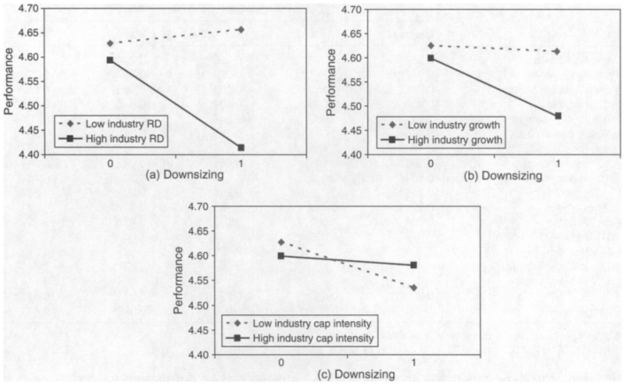

**text found inside the figure**

4.65

- - Low industry cap intensity

(c) Downsizing

industry variables took values of one standard deviation below and one standard deviation above the mean. Fig ure 1(a) illustrates that there is much stronger negative

relationship between downsizing and performance when R&D intensity is high. As such, our data and analysis

provide strong support for Hypothesis 1.

Similarly, the significance (p < 0.05) of the interaction term involving industry growth and workforce reduc tions indicates that the relationship between workforce reductions and firm performance is also moderated by

industry growth. The plot of the interaction is dis played in Figure 1(b). The plot highlights that for firms

in industries characterized by high growth, downsizing is associated with greater negative impact; in contrast, downsizing has very little impact on firm performance

in industries characterized by low growth. Thus, the results indicate that workforce downsizing has a greater negative impact on subsequent firm performance under circumstances of higher industry growth, supporting Hypothesis 2.

MRA results also indicate support for the moderat ing effect of industry capital intensity (Hypothesis 3), with the negative impact increasing as capital intensity

decreases (p < 0.05). As indicated in Figure 1(c), the

significant interaction term indicates that while the effect of downsizing on firm performance is negative in both

low and high capital-intensity industries, the relationship is more pronounced in lower capital-intensity industries. Finally, we find no support for the prediction that indus

try dynamism moderates the relationship between down sizing and firm performance. In sum, our results provide

support for three of the four moderating effects, support ing the general proposition that industry characteristics influence the relationship between workforce downsiz ing and subsequent firm performance.

### Discussion and Conclusions

Both a universal approach and a contingency approach

have been used in the SHRM literature to model the link

between HRM?the policies and practices used to man

age employees?and firm effectiveness (Youndt et al.

1996). The universal approach suggests that HR pol icy and practice effectiveness will be similar, regardless of organizational context. In contrast, the contingency approach proposes that the extent (or even the direction) of the effect of HR practices on firm performance will depend on a firm's context or environmental conditions.

Our study focused specifically on the practice of downsizing and provides support for both perspectives. First, our results support arguments (e.g., Pfeffer 1998, Reichheld 1996) and previous findings (e.g., Cascio

et al. 1997, Worrell et al. 1991) that workforce down

sizing has a deleterious effect on firm performance. Second, we illustrate the potential for industry con

text to moderate the relationship between downsizing and organizational performance. We observed signifi cant contingency effects, with industry characteristics magnifying the negative effects of downsizing on firm

performance. As evidenced by the significant additional variance explained by the interaction term, our results are particularly supportive of arguments that downsiz

ing will be more harmful in R&D-intensive industries.

Page 13

Guthrie and Datta: The Impact of Downsizing on Firm Performance

Organization Science 19(1), pp. 108-123, ?2008 INFORMS 119

We attribute these results to the relatively greater con

tribution of HR endowments to success in such indus

tries. The loss of critical human and social capital, coupled with the lower commitment and greater rigid

ity on the part of "survivors," probably contributes to the heightened negative effects of downsizing in R&D intensive industries. Examples of R&D-intensive indus tries in our sample include pharmaceuticals, biological products, and specialized electronic components (com munications, computing, etc.)?industries that are very

similar to those projected by Cascio (2002) as the kinds of knowledge-intensive industries in which downsizing will be particularly problematic.

experiencing high growth are less likely to downsize. However, those that do downsize in the context of indus

try growth perform more poorly in subsequent years. As argued earlier, although organizational restructuring via downsizing may be anticipated and deemed more accept able by employees in mature or declining industries, this would be less so in growth industries. As indicated by

our results, job cuts during a time of market expansion may be particularly harmful to employee morale and

commitment, thereby reducing organizational effective ness. This interpretation is supported by previous survey

research reporting that layoffs are perceived to be more "fair" if justified by reduced product demand (Charness and Levine 2000). Finally, we find that as labor inten

sity increases (or as capital intensity decreases), perfor mance effects following downsizing worsen somewhat.

Our interpretation of this result is fairly straightforward:

In industries marked by low capital intensity, firm per formance is impacted more substantially by labor inputs and, by extension, the harmful effects of downsizing on human and organizational social capital.

The objective of this study was to contribute to the growing literature on the effects of employee downsiz

ing. From a research perspective, our examination of the role of industry characteristics in moderating the re lationship between workforce reduction and firm per formance fills an important void in the literature on employee downsizing. It also highlights the importance of specifically incorporating (or at least controlling for)

industry conditions in future studies on employee down sizing. From a managerial standpoint, our study suggests that a firm's industry affects the success (or lack thereof) of employee downsizing efforts. As our results indicate, downsizing can be particularly detrimental in certain kinds of industries?those characterized by higher lev

els of R&D, growth, and labor intensity (i.e., low cap

ital intensity). Overall, our findings lend support to the contention that workforce reductions often have negative consequences and these consequences can be magnified

by industry conditions. These results suggest that man

agers need to carefully consider the industry context in making decisions related to employee cutbacks.

Our results may also help explain conflicting results reported previously. If samples are drawn from single or a limited set of industries, then the particular fea

tures of these industries may have undue influence on the performance effects associated with downsizing. For example, based on study findings, one can conclude that

the negative effects of downsizing are more likely to be observed if sample firms are skewed toward high growth, knowledge-intensive, and labor-intensive indus

tries. Alternatively, studies examining firms drawn from industries having contrasting features (i.e., low growth, low tech, etc.) are more likely to reveal neutral to posi tive effects of downsizing on firm performance.

It is also worth noting that downsizing study results may also be influenced by researchers' choice of "firm

performance" measures. As measures of the extent to which revenues are being efficiently generated by a

committed labor force working both "smart and hard," we believe that efficiency-based measures (e.g., ROA)

reflect the organizational impact of any erosion (or

improvements) in a firm's stock of human and social capital. In contrast, market-based measures are more distant from workers and, when used in the context

of event study methodology, strongly influenced by

the information context surrounding announcements of workforce reductions (Palmon et al. 1997, Worrell et al.

1991).

Although our study provides interesting insights into

the relationships among workforce reductions, industry conditions, and firm performance, our findings should be interpreted in the context of limitations inherent in

this study. For example, one legitimate concern is the

question of causality. We control for prior performance

and test for performance effects in multiple years follow

ing employment level changes, but our design does not completely rule out the possibility of reverse causality. Moreover, we do not have a direct measure of down

sizing, instead measuring workforce reductions across a specific timeframe. However, we do provide evidence strongly suggesting that this measure reflects organiza tional downsizing initiatives.

Also, the fact that our study was based on firms only

in the manufacturing sector limits the generalizability of our findings. Future studies should attempt to examine

similar relationships in the service sector. It seems rea sonable to expect that the damage to human and social capital wrought by unstable employment relationships

may be particularly disruptive in contexts where employ

ees interact more directly with customers and clients

(Reichheld 1996). In addition, we examined the mod erating effects of industry characteristics, but we were not in a position to specifically test for the mediating

Page 14

Guthrie and Datta: The Impact of Downsizing on Firm Performance

120 Organization Science 19(1), pp. 108-123, ?2008 INFORMS

effects of various factors (e.g., the impact of psycholog

ical contract violations, disruptions to social capital, and social dynamics) that underlie the hypothesized effects of downsizing on performance in different industry con

texts. Future research that examines the role of such

mediators will certainly contribute to the downsizing lit

erature and augment the findings of our study.

Our investigation of the effects of workforce reduc tions on firm performance was not as refined as the oretical treatments might suggest. The work of both Lepak and Snell (1999) and Delery and Shaw (2001)

suggest that the impact of HR systems and, more specifically, employee retention will vary depending on whether employees are part of a firm's "strategic core." Delery and Shaw (2001), for example, note that firms

such as McDonalds have experienced competitive suc cess despite very high turnover rates. They argue that

such firms are not adversely impacted by high turnover rates because these particular employees are not criti cal to their core competencies. By extension, firm per formance may be more or less impacted depending on whether "strategic" employees are "made redun dant." Thus, based on these theoretical frameworks,

a more refined future study might identify the "strate gic" and "non-strategic" employee groups within firms or industries and study the differential performance

impacts of unstable employment relationships across these employee groups.

Another issue is the possibility of survey non-response bias. We provide a number of formal tests for this potential confound; however, we cannot ascertain with

certainty whether respondents and nonrespondents dif fer on unmeasured variables that may also correlate with both our predictor and dependent variables. Finally, while we do control for a number of important influ

ences on downsizing and/or firm performance, we do not capture all these influences. For example, to the

extent that downsizing decisions represent a form of "management myopia," then models controlling for other decisions representing management "short sightedness" would more effectively isolate the specific impact of

downsizing decisions.5

While this paper argues and tests for the industry con ditions as important contingency factors, future research

should also explore the moderating effects of firm-level contingency factors. For example, we argue that down

sizing in the context of market growth will be more problematic because employees will perceive this as less

justified and less acceptable. Similar arguments could be argued in the context of firm performance. Employees

should find downsizing in the context of deteriorating or inferior performance to be relatively more acceptable, perceiving this as a legitimate attempt to "right the ship." Employees in firms that are healthy, however, may have

a very different reaction to downsizing, finding it a viola

tion of the implicit contract suggesting that higher levels

of firm performance reflect superior employee contribu

tions, which, in turn, should be rewarded with enhanced

employment opportunities.6

This study adds to the body of evidence question ing the efficacy of workforce downsizing. Although management actions can mitigate negative impacts (cf.

Chadwick et al. 2004), it is increasingly apparent that, more often than not, layoffs and downsizing result in

firms being relatively more "lean and lame" than "lean

and mean." Moreover, our results suggest that this neg ative impact may be magnified, depending on a firm's

industry or market conditions. Much work remains, how ever, in identifying other organizational and contextual conditions that influence the impact of workforce down

sizing on firm performance. We hope this study informs and stimulates further work in this regard.

Acknowledgments

This research was partially supported by grants from the Soci

ety for Human Resource Management (SHRM) Foundation,

the Eunice and James West Endowment at the University of Texas at Arlington, and the General Research Fund at the Uni

versity of Kansas. The authors thank two anonymous review ers and Senior Editor Susan Taylor for their valuable com ments and suggestions. An earlier version of this paper was

presented at the 2005 Academy of Management Annual Meet

ing in Honolulu, Hawaii.

#### Endnotes

]For example, recent figures indicate that during the years 2003 and 2004, more than 3 million workers lost jobs through

layoffs (Bureau of Labor Statistics [BLS] 2004). However, because the BLS figures only record "mass" layoffs, defined

as those involving 50 or more employees, these figures sig nificantly underreport the actual number of employees los

ing jobs through layoffs. A recent example is IBM. On May 4, 2005, on the heels of sagging profits, IBM announced

job cuts ("restructuring") amounting to 13,000 employees, or about 4% of its workforce. Over the last 20 years, IBM's "restructuring" has resulted in tens of thousands of job cuts

(Forelle 2005). Even the AFL-CIO?an ardent advocate of job security?recently announced the elimination of one-quarter of its workforce (International Labor Communications Asso ciation (ILCA) Online 2005). 2Categorizing firms into "downsizers" and "nondownsizers," as opposed to using a continuous measure of employment

level change, is consistent with almost all previous research on downsizing. It is also consistent with a research focus on

the effects of workforce reductions. A continuous measure

of employment level includes firms that are both declining and growing in employment. Ahmadjian and Robinson (2001, p. 632) make the explicit case for a dichotomous measure, noting: "A dichotomous measure of downsizing is also eas

ier to interpret than a continuous measure that captures both an increase and a decrease in employment." Moreover, the organizational effects of employee growth are not expected

to be symmetrical with the effects of employee downsizing (McKinley 1992). 3Despite this rationale, the 5% decision rule is still some what arbitrary. Thus, in addition to a 5% decrease in the

Page 15

Guthrie and Datta: The Impact of Downsizing on Firm Performance

Organization Science 19(1), pp. 108-123, ?2008 INFORMS 121

level of employment, we also used 3%, 7%, and 10% changes in employment levels to categorize firms as "downsizers" or "nondownsizers." These alternative classification criteria

resulted in no substantive change in study results and conclu sions. Results are robust across these alternative operational izations of downsizing. 4Scholars have raised issues about the reliability of measures of HR practices based on a single organizational respondent

(e.g., Gerhart et al. 2000, Huselid and Becker 2000). For a subset of our sample firms (n = 33) we had multiple responses on the HR variables, allowing us to compute the intraclass cor

relation coefficient, ICC(l), as a check on the reliability of our HR data. ICC(l) can be conceptualized as the proportion of

variance in a measure explained by group membership (Bryk and Raudenbush 1992). As noted by Bliese (2000, p. 356), "When ICC(l) is large, a single rating from an individual is

likely to provide a relatively reliable rating of the group mean; When ICC(l) is small, multiple ratings are necessary to pro

vide reliable estimates of the group mean." For the measure of unionization, the ICC(l) value is 0.59 and for the employment

security measure, the ICC(l) value is 0.40. Based on avail able standards (e.g., Bliese 2000, Gerhart et al. 2000), these values would be characterized as "large" and supportive of an acceptable degree of agreement across raters.

5The authors thank an anonymous reviewer for suggesting this point.

6The authors thank an anonymous reviewer for making this suggestion. In fact, our data suggest that this may be the case. When we divide our sample based on the median value for pre

downsizing performance, we find that firms among the "high performing" group that downsize perform significantly worse

in subsequent years relative to firms that do not downsize. Among the "low-performing" group, downsizing has no effect

on subsequent performance.

#### References

Ahmadjian, C. L., P. Robinson. 2001. Safety in numbers: Downsizing

and deinstitutionalization of permanent employment in Japan. Admin. Sci. Quart. 46 622-658.

Aiken, L. S., S. G. West. 1991. Multiple Regression: Testing and

Interpreting Interactions. Sage, Newbury Park, CA.

Amabile, T. M, R. Conti. 1999. Changes in the work environment for

creativity during downsizing. Acad. Management J. 42 630-640.

Aragon-Correa, J. A., S. Sharma. 2003. A contingent resource-based

view of proactive corporate environmental strategy. Acad. Man agement Rev. 28 71-88.

Armstrong, S. J., T. S. Overton. 1977. Estimating non-response bias

in mail surveys. J. Marketing Res. 14 396-402.

Bain, J. S., P. D. Quails. 1987. Industrial Organization: A Treatise.

JAI Press, Greenwich, CT.

Bamberger, P., I. Meshoulam. 2000. Human Resource Strategy:

Formulation, Implementation and Impact. Sage Publications, Thousand Oaks, CA.

Bamberger, P., B. Phillips. 1991. Organizational environment and

business strategy: Parallel versus conflicting influences on

human resource strategy in the pharmaceutical industry. Human Resource Management 30 153-182.

Batt, R. 2002. Managing customer services: Human resource prac

tices, quit rates, and sales growth. Acad. Management J. 45 587-597.

Baum, J. R., W. Stefan. 2003. Strategic decision speed and firm per

formance. Strategic Management J. 24 1107-1129.

Baumol, W. J., A. Blinder, A. E. N. Wolff. 2003. Downsizing in Amer

ica: Reality, Causes, and Consequences. Russell Sage Founda tion, New York.

Becker, B. E., M. A. Huselid. 1998. High performance work sys

tems and firm performance: A synthesis of research and man agerial implications. K. M. Rowland, G. R. Ferris, eds. Research

in Personnel and Human Resource Management. JAI Press, Greenwich, CT, 53-101.

Berk, R. A. 1983. An introduction to sample selection bias in socio

logical data. Amer. Sociol. Rev. 48 386-398.

Bliese, P. 2000. Within-group agreement, non-independence, and

reliability: Implications for data aggregation and analysis. K. J. Klein, S. W. J. Kozlowski, eds. Multilevel Theory, Research, and Methods in Organizations. Jossey Bass, San

Francisco, CA, 349-381.

Bruton, G, J. Keels, C. Shook. 19%. Downsizing the firm: Answering

the strategic questions. Acad. Management Executive 10 38-45.

Bryk, A. S., S. W. Raudenbush. 1992. Hierarchical Linear Models.

Sage, Newbury Park, CA.

Bryne, J. A. 1994. There is an upside to downsizing. Bus. Week

9(May) 69.

Budros, A. 1999. A conceptual framework for analyzing why organi

zations downsize. Organ. Sci. 10 69-82.

Bureau of Labor Statistics. 2004. Mass Layoffs (Monthly). http://stats.

bls.gov/news.release/mmls.toc.htm.

Burns, T, G. M. Stalker. 1961. The Management of Innovation.

Tavistock, London.

Burt, R. 1997. The contingent value of social capital. Admin. Sci.

Quart. 42 339-365.

Cameron, K. S. 1994. Investigating organizational downsizing: Fun

damental issues. Human Resource Management 33 183-188.

Cameron, K. S., S. J. Freeman, A. K. Mishra. 1991. Best practices in

white collar downsizing: Managing contradictions. Acad. Man

agement Executive 5 57-73.

Cameron, K. S., D. A. Whetton, M. U. Kim. 1987. Organizational

dysfunctions of decline. Acad. Management J. 30 126-138.

Cannella, A., W. Shen. 2001. So close and yet so far: Promotion

versus exit for CEO heirs apparent. Acad. Management J. 44 252-271.

Cappelli, P. 1999. The New Deal at Work: Managing the Market

Driven Workforce. Harvard Business School Press, Boston, MA.

Cappelli, P. 2000. Examining the incidence of downsizing and its

effect on establishment performance. NBER Working Paper 7742, National Bureau of Economic Research, Inc., Cambridge, MA.

Cascio, W. 1993. Downsizing: What do we know? What have we

learned? Acad. Management Executive 7 95-103.

Cascio, W. F. 2002. Responsible Restructuring: Creative and Prof

itable Alternatives to Layoffs. Berrett-Koehler, San Fransisco, CA.

Cascio, W., C. E. Young, J. R. Morris. 1997. Financial consequences

of employment-change decisions in major U.S. corporations. Acad. Management J. 40 1175-1189.

Caves, R., M. Krepps. 1993. Fat: The displacement of nonproduction

workers from U.S. manufacturing industries. Brookings Papers Econom. Activity: Microeconomics (2) 227-288.

Page 16

Guthrie and Datta: The Impact of Downsizing on Firm Performance

122 Organization Science 19(1), pp. 108-123, ? 2008 INFORMS

Chadwick, C, L. W. Hunter, S. L. Walston. 2004. Effects of down

sizing practices on the performance of hospitals. Strategic Man agement J. 25 405^27.

Chang, S. J., H. Singh. 1999. The impact of modes of entry and

resource fit on modes of exit by multibusiness firms. Strategic Management J. 20 1019-1035.

Charness, G., D. I. Levine. 2000. When are layoffs acceptable? Evi

dence from a quasi-experiment. Indust. Labor Relations Rev. 53 381-200.

Chatman, J. A., K. A. Jehn. 1994. Assessing the relationship between

industry characteristics and organizational culture: How different can you be? Acad. Management J. 37 522-533.

Datta, D. K., N. Rajagopalan. 1998. Industry structure and CEO char

acteristics: An empirical study of succession events. Strategic Management J. 19 833-852.

Datta, D. K., J. P. Guthrie, P. M. Wright. 2005. HRM and labor

productivity: Does industry matter? Acad. Management J. 48

135-145.

Delery, J. E., H. D. Doty. 1996. Modes of theorizing in strategic

human resource management: Tests of universalistic, contin gency and configurational performance predictions. Acad. Man agement J. 39(4) 802-835.

Delery, J. E., J. D. Shaw. 2001. The strategic management of peo

ple in work organizations: Review, synthesis and extension. K. M. Rowland, G. R. Ferris, eds. Research in Personnel and Human Resource Management. JAI Press, Greenwich, CT, 165

197.

De Meuse, K. P., W. W. Tornow. 1990. The tie that binds?

Has become very, very frayed! Human Resource Planning 13

203-213.

Dess, G G, J. D. Shaw. 2001. Voluntary turnover, social capital,

and organizational performance. Acad. Management Rev. 26 446-456.

DeWitt, R. 1998. Firm, industry, and strategy influences on choice of

downsizing approach. Strategic Management J. 19 59-80.

Dougherty, D., E. H. Bowman. 1995. The effects of organizational

downsizing on product innovation. California Management Rev. 37(4) 28-34.

Edwards, J. R., M. E. Parry. 1993. On the use of polynomial regres

sion equations as an alternative to difference scores in organiza tional research. Acad. Management Rev. 36 1577-1613.

Espahbodi, R., T. A. John, G Vasudevan. 2000. The effects of down

sizing on operating performance. Rev. Quant. Finance Account ing 15 107-126.

Farber, H. S. 1997. The changing face of job loss in the United

States: 1981-1995. Brookings Papers Econom. Activity: Microe conomics 55-128.

Filatotchev, I., T. Buck, V. Zhukov. 2000. Downsizing in privatized

firms in Russia, Ukraine, and Belarus. Acad. Management J. 43 286-304.

Forelle, C. 2005. IBM plans restructuring, job cuts. Wall Street J.

(May 5) A3.

Freeman, S. J. 1994. Organizational downsizing as convergence or

reorientation: Implications for human resource management. Human Resource Management 33 213-238.

Freeman, S. J., K. Cameron. 1993. Organizational downsizing: A con

vergence and reorientation framework. Organ. Sci. 4 10-29.

Fuchsberg, G 1993. Why shakeups work for some, not for others.

Wall Street J. (October 1) Bl, B5.

Gerhart, B., P. Wright, G. McMahan, S. Snell. 2000. Error in research

on human resources and firm performance: How much error is

there and how does it influence effect size estimates? Personnel Psych. 53 803-834.

Grant, R. M. 2005. Contemporary Strategic Analysis. Blackwell Pub

lishing, Oxford, UK.

Guthrie, J. P. 2001. High involvement work practices, turnover and

productivity: Evidence from New Zealand. Acad. Management J. 44 180-190.

Guthrie, J. P., C. M. Grimm, K. G Smith. 1991. Environmental

change and management staffing: An empirical study. J. Man agement 17 735-748.

Guthrie, J. P., J. D. Olian. 1991. Does context affect staffing? The

case of general managers. Personnel Psych. 44 263-292.

Haleblian, J., S. Finkelstein. 1993. Top management team size, CEO

dominance, and firm performance: The moderating roles of envi

ronmental turbulence and discretion. Acad. Management J. 36 844-863.

Hambrick, D. C, C. Abrahamson. 1995. Assessing the amount of

managerial discretion in different industries: A multi-method

approach. Acad. Management J. 38 1427-1441.

Hambrick, D. C, A. A. Cannella. 2004. CEOs who have COOs:

Contingency analysis of an unexplored structural form. Strategic Management J. 25 959-979.

Hambrick, D. C, S. Finkelstein. 1987. Managerial discretion:

A bridge between polar views on organizations. L. L. Cum mings, B. M. Staw, eds. Research in Organizational Behavior, Vol. 9. JAI Press, Greenwich, CT, 369-406.

Hambrick, D. C, D. Lei. 1985. Toward an empirical prioritization of

contingency variables for business strategy. Acad. Management J. 28 763-788.

Harrigan, K. R. 1980. Strategy formulation in declining industries.

Acad. Management Rev. 5 599-605.

Heckman, J. J. 1979. Sample selection bias as a specification error.

Econometrica 47 153-161.

Henkoff, R. 1994. Getting beyond downsizing. Fortune 129(1) 58-64.

Huselid, M. A. 1995. The impact of human resource management

practices on turnover, productivity, and corporate. Acad. Man agement J. 38 635-672.

Huselid, M. A., B. E. Becker. 2000. Comment on "Measurement error

on research on human resources and firm performance: How much error is there and does it influence effect size estimates."

Personnel Psych. 53 835-854.

ILCA Online. 2005. Cuts and fissures: The AFL-CIO announces lay

offs. http://www.ilcaonline.org/.

Jackson, S. E., R. S. Schuler. 1995. Understanding human resource

management in the context of organizations and their environ ments. Annual Rev. Psych. 46 237-264.

Keats, B., M. A. Hitt. 1988. Causal model of linkages among envi

ronmental dimensions, macro organizational characteristics, and performance. Acad. Management J. 31 570-598.

Kets deVries, M. F. R., K. Balzas. 1997. The downside of downsizing.

Human Relations 50(1) 11-50.

Koch, M. J., R. G McGrath. 1996. Improving labor productivity:

Human resource management policies do matter. Strategic Man

agement J. 17 335-354.

Koretz, G 1997. Big payoffs from layoffs. Bus. Week 30 (February 24).

Lawrence, P., J. Lorsch. 1967. Organization and Environment. Har

vard Business School, Boston, MA.

Page 17

Guthrie and Datta: The Impact of Downsizing on Firm Performance Organization Science 19(1), pp. 108-123, ?2008 INFORMS 123

Leana, C. R., H. J. Van Buren. 2000. Eroding organizational social

capital among U.S. firms: Price of job instability. R. J. Burke, C. L. Cooper, eds. Downsizing, Restructuring, and Privatization. Blackwell Publishers, Oxford, UK, 220-232.

Lee, C. 1997. Trust me. Training 34(1) 28-37.

Lepak, D. P., S. A. Snell. 1999. The human resource architecture:

Toward a theory of human capital allocation and development. Acad. Management J. 24 31-48.

Lepak, D. P., R. Takeuchi, S. A. Snell. 2003. Employment flexibil

ity and firm performance: Examining the interaction effects of employment mode, environmental dynamism, and technological

intensity. J. Management 29 681-703.

Levering, R., M. Moskowitz. 1993. The 100 Best Companies to Work

for in America. Penguin Books, New York.

Levering, R., M. Moskowitz. 1997. The 100 best companies to work

for in America. Fortune 137(1) 84-95.

Littler, C. R., P. Innes. 2004. The paradox of managerial downsizing.

Organ. Stud. 25 1159-1184.

McKinley, W. 1992. Decreasing organizational size: To untangle or

not to untangle? Acad. Management Rev. 17 112-123.

McKinley, W., M. A. Mone, V Barker. 1998. Some ideological foun

dations of organizational downsizing. J. Management Inquiry 7

198-212.

McKinley, W., J. Zhao, K. Rust. 2000. A socio-cognitive interpreta

tion of organizational downsizing. Acad. Management Rev. 25 227-233.

Morris, J. R., W. R. Cascio, C. E. Young. 1999. Downsizing after

all these years: Questions and answers about who did it, how

many did it, and who benefited from it. Organ. Dynam. 27(3)

78-87.

Morrison, E. W., S. L. Robinson. 1997. When employees feel

betrayed: A model of how psychological contract violation develops. Acad. Management Rev. 22 226-256.

Murray, M. 1995. Amid record profits, companies continue to lay off

employees. Wall Street J. (May 4) Al, A4.

Myers, R. H. 1990. Classical and Modern Regression with Applica

tions, 2nd ed. Duxbury Press, Belmont, CA.

Neter, J., W Wasserman, M. H. Kutner. 1985. Applied Linear Statis

tical Models. Irwin, Homewood, IL.

Nixon, R. D., M. A. Hitt, H. Lee, E. Jeong. 2004. Market reactions to

announcements of corporate downsizing actions and implemen

tation strategies. Strategic Management J. 25 1121-1129.

Oppenheim, A. N. 1966. Questionnaire Design and Attitude Measure

ment. Basic Books, Inc., New York.

Palmon, O., H. Sun, A. Tang. 1997. Layoff announcements: Stock

market impact and financial performance. Financial Manage ment 26 54-68.

Penrose, E. 1959. The Theory of the Growth of the Firm. Oxford

University Press, Oxford, UK.

Pfeffer, J. 1998. The Human Equation: Building Profits by Putting

People First. Harvard Business School Press, Boston, MA.

Pfeffer, J., G. R. Salancik. 1978. The External Control of Organi

zations: A Resource Dependence Perspective. Harper and Row, New York.

Porter, M. E. 1980. Competitive Strategy. The Free Press, New York.

Rajagopalan, N., D. K. Datta. 1996. CEO characteristics: Does indus

try matter? Acad. Management J. 39 197-215.

Reichheld, F. F. 1996. The Loyalty Effect: The Hidden Force Behind

Growth, Profits, and Lasting Value. Harvard Business School Press, Cambridge, MA.

Rousseau, D. M. 1995. Psychological Contracts in Organizations:

Understanding Written and Unwritten Agreements. Sage Publi

cations, Thousand Oaks, CA.

Scherer, F. M. 1980. Industrial Market Structure and Economic Per

formance. Rand McNally, Chicago, IL.

Selznick, P. 1957. Leadership in Administration: A Sociological Inter

pretation. Row, Peterson, and Co., Evanston, IL.

Siegel, P. A., D. C. Hambrick. 2005. Pay disparities within top man

agement groups: Evidence of harmful effects on performance in high-technology firms. Organ. Sci. 16 259-274.

Terpstra, D. E., E. J. Rozzell. 1993. The relationship of staffing prac

tices to organizational level measures of performance. Personnel Psych. 46 27-48.

Thompson, J. A. 1967. Organizations in Action. McGraw-Hill, New

York.

Venkatraman, N. 1989. Strategic orientation of business enterprises:

The construct, dimensionality, and measurement. Management

Sci. 35 942-962.

Wayhan, V. B., S. Werner. 2000. The impact of workface reductions

on financial performance: A longitudinal perspective. J. Man agement 26 341-363.

Wernerfelt, B. 1984. A resource-based view of the firm. Strategic

Management J. 5 171-180.

Worrell, D. L., W. N. Davidson III, V. M. Sharma. 1991. Layoff

announcements and stockholder wealth. Acad. Management J. 43 662-678.

Wright, P. M., S. A. Snell. 1998. Toward a unifying framework for

exploring fit and flexibility in strategic human resource manage ment. Acad. Management Rev. 23 756-772.

Youndt, M. A., S. A. Snell, J. W. Dean, D. P. Lepak. 1996. Human

resource management, manufacturing strategy, and firm perfor mance. Acad. Management J. 39 836-865.

Zahra, S. A., J. G. Covin. 1993. Business strategy, technological pol

icy and firm performance. Strategic Management J. 14 451^78.

Zhang, Y, N. Rajagopalan. 2004. When the known devil is better than

an unknown god: An empirical study of the antecedents and consequences of relay CEO successions. Acad. Management J. 47 483-500.